# Risk Factor Analysis

## Outcome Variable

**Outcome Variable:** stunted

## Predictor Variables

**Intervention Variable:** mbmi

**Adjustment Set:**

unadjusted

## Stratifying Variables

The analysis was stratified on these variable(s):

- agecat
- studyid
- country

## Data Summary

| agecat | studyid | country | mbmi | stunted | n_cell | n |
| --- | --- | --- | --- | --- | --- | --- |
| Birth | ki0047075b-MAL-ED | BANGLADESH | Normal weight | 0 | 130 | 246 |
| Birth | ki0047075b-MAL-ED | BANGLADESH | Normal weight | 1 | 28 | 246 |
| Birth | ki0047075b-MAL-ED | BANGLADESH | Underweight | 0 | 25 | 246 |
| Birth | ki0047075b-MAL-ED | BANGLADESH | Underweight | 1 | 5 | 246 |
| Birth | ki0047075b-MAL-ED | BANGLADESH | Overweight or Obese | 0 | 49 | 246 |
| Birth | ki0047075b-MAL-ED | BANGLADESH | Overweight or Obese | 1 | 9 | 246 |
| Birth | ki0047075b-MAL-ED | BRAZIL | Normal weight | 0 | 62 | 184 |
| Birth | ki0047075b-MAL-ED | BRAZIL | Normal weight | 1 | 8 | 184 |
| Birth | ki0047075b-MAL-ED | BRAZIL | Underweight | 0 | 7 | 184 |
| Birth | ki0047075b-MAL-ED | BRAZIL | Underweight | 1 | 2 | 184 |
| Birth | ki0047075b-MAL-ED | BRAZIL | Overweight or Obese | 0 | 96 | 184 |
| Birth | ki0047075b-MAL-ED | BRAZIL | Overweight or Obese | 1 | 9 | 184 |
| Birth | ki0047075b-MAL-ED | INDIA | Normal weight | 0 | 96 | 198 |
| Birth | ki0047075b-MAL-ED | INDIA | Normal weight | 1 | 21 | 198 |
| Birth | ki0047075b-MAL-ED | INDIA | Underweight | 0 | 32 | 198 |
| Birth | ki0047075b-MAL-ED | INDIA | Underweight | 1 | 7 | 198 |
| Birth | ki0047075b-MAL-ED | INDIA | Overweight or Obese | 0 | 38 | 198 |
| Birth | ki0047075b-MAL-ED | INDIA | Overweight or Obese | 1 | 4 | 198 |
| Birth | ki0047075b-MAL-ED | NEPAL | Normal weight | 0 | 88 | 172 |
| Birth | ki0047075b-MAL-ED | NEPAL | Normal weight | 1 | 11 | 172 |
| Birth | ki0047075b-MAL-ED | NEPAL | Underweight | 0 | 0 | 172 |
| Birth | ki0047075b-MAL-ED | NEPAL | Underweight | 1 | 0 | 172 |
| Birth | ki0047075b-MAL-ED | NEPAL | Overweight or Obese | 0 | 66 | 172 |
| Birth | ki0047075b-MAL-ED | NEPAL | Overweight or Obese | 1 | 7 | 172 |
| Birth | ki0047075b-MAL-ED | PERU | Normal weight | 0 | 130 | 276 |
| Birth | ki0047075b-MAL-ED | PERU | Normal weight | 1 | 19 | 276 |
| Birth | ki0047075b-MAL-ED | PERU | Underweight | 0 | 3 | 276 |
| Birth | ki0047075b-MAL-ED | PERU | Underweight | 1 | 2 | 276 |
| Birth | ki0047075b-MAL-ED | PERU | Overweight or Obese | 0 | 110 | 276 |
| Birth | ki0047075b-MAL-ED | PERU | Overweight or Obese | 1 | 12 | 276 |

[output cut: 216 more lines]

The following strata were considered:

- agecat: 24 months, studyid: ki0047075b-MAL-ED, country: BANGLADESH
- agecat: 24 months, studyid: ki0047075b-MAL-ED, country: BRAZIL
- agecat: 24 months, studyid: ki0047075b-MAL-ED, country: INDIA
- agecat: 24 months, studyid: ki0047075b-MAL-ED, country: NEPAL
- agecat: 24 months, studyid: ki0047075b-MAL-ED, country: PERU
- agecat: 24 months, studyid: ki0047075b-MAL-ED, country: SOUTH AFRICA
- agecat: 24 months, studyid: ki0047075b-MAL-ED, country: TANZANIA, UNITED REPUBLIC OF
- agecat: 24 months, studyid: ki1017093-NIH-Birth, country: BANGLADESH
- agecat: 24 months, studyid: ki1017093b-PROVIDE, country: BANGLADESH
- agecat: 24 months, studyid: ki1017093c-NIH-Crypto, country: BANGLADESH
- agecat: 24 months, studyid: ki1066203-TanzaniaChild2, country: TANZANIA, UNITED REPUBLIC OF
- agecat: 24 months, studyid: ki1119695-PROBIT, country: BELARUS
- agecat: 24 months, studyid: ki1126311-ZVITAMBO, country: ZIMBABWE
- agecat: 24 months, studyid: ki1148112-LCNI-5, country: MALAWI
- agecat: 6 months, studyid: ki0047075b-MAL-ED, country: BANGLADESH
- agecat: 6 months, studyid: ki0047075b-MAL-ED, country: BRAZIL
- agecat: 6 months, studyid: ki0047075b-MAL-ED, country: INDIA
- agecat: 6 months, studyid: ki0047075b-MAL-ED, country: NEPAL
- agecat: 6 months, studyid: ki0047075b-MAL-ED, country: PERU
- agecat: 6 months, studyid: ki0047075b-MAL-ED, country: SOUTH AFRICA
- agecat: 6 months, studyid: ki0047075b-MAL-ED, country: TANZANIA, UNITED REPUBLIC OF
- agecat: 6 months, studyid: ki1000304b-SAS-CompFeed, country: INDIA
- agecat: 6 months, studyid: ki1017093-NIH-Birth, country: BANGLADESH
- agecat: 6 months, studyid: ki1017093b-PROVIDE, country: BANGLADESH
- agecat: 6 months, studyid: ki1017093c-NIH-Crypto, country: BANGLADESH
- agecat: 6 months, studyid: ki1066203-TanzaniaChild2, country: TANZANIA, UNITED REPUBLIC OF
- agecat: 6 months, studyid: ki1119695-PROBIT, country: BELARUS
- agecat: 6 months, studyid: ki1126311-ZVITAMBO, country: ZIMBABWE
- agecat: 6 months, studyid: ki1148112-LCNI-5, country: MALAWI
- agecat: Birth, studyid: ki0047075b-MAL-ED, country: BANGLADESH
- agecat: Birth, studyid: ki0047075b-MAL-ED, country: BRAZIL
- agecat: Birth, studyid: ki0047075b-MAL-ED, country: INDIA
- agecat: Birth, studyid: ki0047075b-MAL-ED, country: NEPAL
- agecat: Birth, studyid: ki0047075b-MAL-ED, country: PERU
- agecat: Birth, studyid: ki0047075b-MAL-ED, country: SOUTH AFRICA
- agecat: Birth, studyid: ki0047075b-MAL-ED, country: TANZANIA, UNITED REPUBLIC OF
- agecat: Birth, studyid: ki1000304b-SAS-CompFeed, country: INDIA
- agecat: Birth, studyid: ki1017093-NIH-Birth, country: BANGLADESH
- agecat: Birth, studyid: ki1017093c-NIH-Crypto, country: BANGLADESH
- agecat: Birth, studyid: ki1119695-PROBIT, country: BELARUS
- agecat: Birth, studyid: ki1126311-ZVITAMBO, country: ZIMBABWE

### Dropped Strata

Some strata were dropped due to rare outcomes:

- agecat: Birth, studyid: ki0047075b-MAL-ED, country: BRAZIL
- agecat: Birth, studyid: ki0047075b-MAL-ED, country: INDIA
- agecat: Birth, studyid: ki0047075b-MAL-ED, country: NEPAL
- agecat: Birth, studyid: ki0047075b-MAL-ED, country: PERU
- agecat: Birth, studyid: ki0047075b-MAL-ED, country: SOUTH AFRICA
- agecat: Birth, studyid: ki0047075b-MAL-ED, country: TANZANIA, UNITED REPUBLIC OF
- agecat: Birth, studyid: ki1000304b-SAS-CompFeed, country: INDIA
- agecat: Birth, studyid: ki1017093-NIH-Birth, country: BANGLADESH
- agecat: Birth, studyid: ki1017093c-NIH-Crypto, country: BANGLADESH
- agecat: Birth, studyid: ki1119695-PROBIT, country: BELARUS
- agecat: 6 months, studyid: ki0047075b-MAL-ED, country: BRAZIL
- agecat: 6 months, studyid: ki0047075b-MAL-ED, country: NEPAL
- agecat: 6 months, studyid: ki0047075b-MAL-ED, country: PERU
- agecat: 6 months, studyid: ki0047075b-MAL-ED, country: SOUTH AFRICA
- agecat: 6 months, studyid: ki0047075b-MAL-ED, country: TANZANIA, UNITED REPUBLIC OF
- agecat: 6 months, studyid: ki1066203-TanzaniaChild2, country: TANZANIA, UNITED REPUBLIC OF
- agecat: 24 months, studyid: ki0047075b-MAL-ED, country: BRAZIL
- agecat: 24 months, studyid: ki0047075b-MAL-ED, country: NEPAL
- agecat: 24 months, studyid: ki0047075b-MAL-ED, country: PERU
- agecat: 24 months, studyid: ki0047075b-MAL-ED, country: SOUTH AFRICA
- agecat: 24 months, studyid: ki0047075b-MAL-ED, country: TANZANIA, UNITED REPUBLIC OF
- agecat: 24 months, studyid: ki1066203-TanzaniaChild2, country: TANZANIA, UNITED REPUBLIC OF

## Methods Detail

We’re interested in the causal parameters $E[Y_a]$ for all values of $a \in \mathcal{A}$. These parameters represent the mean outcome if, possibly contrary to fact, we intervened to set all units to have $A=a$. Under the randomization and positivity assumptions, these are identified by the statistical parameters $\psi_a=E_W[E_{Y|A,W}(Y|A=a,W)]$. In addition, we’re interested in the mean of $Y$, $E[Y]$ under no intervention (the observed mean). We will estimate these parameters by using SuperLearner to fit the relevant likelihood factors – $E_{Y|A,W}(Y|A=a,W)$ and $p(A=a|W)$, and then updating our likelihood fit using a joint TMLE.

For unadjusted analyses ($W=\{\}$), initial likelihoods were estimated using Lrnr_glm to estimate the simple $E(Y|A)$ and Lrnr_mean to estimate $p(A)$. For adjusted analyses, a small library containing Lrnr_glmnet, Lrnr_xgboost, and Lrnr_mean was used.

Having estimated these parameters, we will then use the delta method to estimate relative risks and attributable risks relative to a prespecified baseline level of $A$.

# Results Detail

## Results Plots

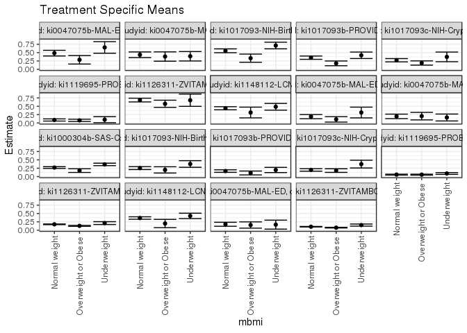

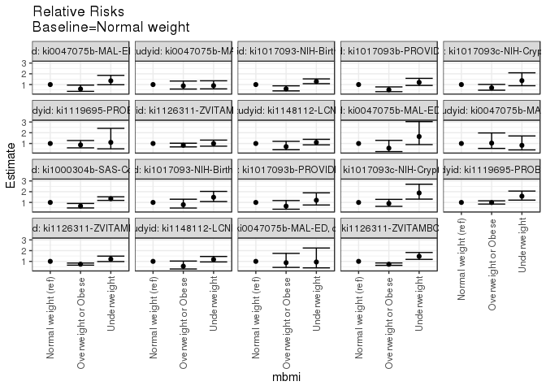

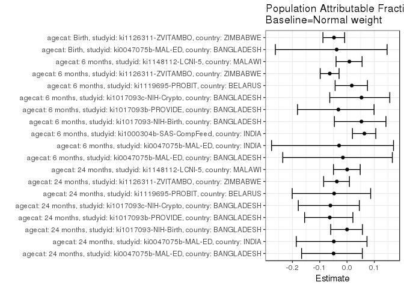

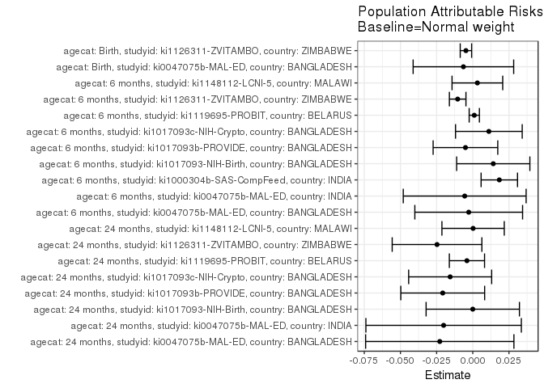

## Results Table

### Parameter: TSM

| agecat | studyid | country | intervention_level | baseline_level | estimate | ci_lower | ci_upper |
| --- | --- | --- | --- | --- | --- | --- | --- |
| Birth | ki0047075b-MAL-ED | BANGLADESH | Normal weight | NA | 0.1772152 | 0.1175532 | 0.2368772 |
| Birth | ki0047075b-MAL-ED | BANGLADESH | Underweight | NA | 0.1666667 | 0.0330361 | 0.3002972 |
| Birth | ki0047075b-MAL-ED | BANGLADESH | Overweight or Obese | NA | 0.1551724 | 0.0618019 | 0.2485430 |
| Birth | ki1126311-ZVITAMBO | ZIMBABWE | Normal weight | NA | 0.1039709 | 0.0966058 | 0.1113360 |
| Birth | ki1126311-ZVITAMBO | ZIMBABWE | Underweight | NA | 0.1529412 | 0.1217016 | 0.1841807 |
| Birth | ki1126311-ZVITAMBO | ZIMBABWE | Overweight or Obese | NA | 0.0760095 | 0.0656742 | 0.0863448 |
| 6 months | ki0047075b-MAL-ED | BANGLADESH | Normal weight | NA | 0.1895425 | 0.1273091 | 0.2517759 |
| 6 months | ki0047075b-MAL-ED | BANGLADESH | Underweight | NA | 0.3125000 | 0.1515699 | 0.4734301 |
| 6 months | ki0047075b-MAL-ED | BANGLADESH | Overweight or Obese | NA | 0.1071429 | 0.0259665 | 0.1883192 |
| 6 months | ki0047075b-MAL-ED | INDIA | Normal weight | NA | 0.1970803 | 0.1303272 | 0.2638334 |
| 6 months | ki0047075b-MAL-ED | INDIA | Underweight | NA | 0.1632653 | 0.0595562 | 0.2669744 |
| 6 months | ki0047075b-MAL-ED | INDIA | Overweight or Obese | NA | 0.2040816 | 0.0909947 | 0.3171685 |
| 6 months | ki1000304b-SAS-CompFeed | INDIA | Normal weight | NA | 0.2701754 | 0.2442538 | 0.2960971 |
| 6 months | ki1000304b-SAS-CompFeed | INDIA | Underweight | NA | 0.3639344 | 0.3268045 | 0.4010644 |
| 6 months | ki1000304b-SAS-CompFeed | INDIA | Overweight or Obese | NA | 0.1791045 | 0.1236550 | 0.2345540 |
| 6 months | ki1017093-NIH-Birth | BANGLADESH | Normal weight | NA | 0.2540107 | 0.2098527 | 0.2981687 |
| 6 months | ki1017093-NIH-Birth | BANGLADESH | Underweight | NA | 0.3763441 | 0.2777896 | 0.4748986 |
| 6 months | ki1017093-NIH-Birth | BANGLADESH | Overweight or Obese | NA | 0.2000000 | 0.1062084 | 0.2937916 |
| 6 months | ki1017093b-PROVIDE | BANGLADESH | Normal weight | NA | 0.1648649 | 0.1270238 | 0.2027059 |
| 6 months | ki1017093b-PROVIDE | BANGLADESH | Underweight | NA | 0.1980198 | 0.1202346 | 0.2758050 |
| 6 months | ki1017093b-PROVIDE | BANGLADESH | Overweight or Obese | NA | 0.1081081 | 0.0502925 | 0.1659237 |
| 6 months | ki1017093c-NIH-Crypto | BANGLADESH | Normal weight | NA | 0.1986755 | 0.1619067 | 0.2354443 |
| 6 months | ki1017093c-NIH-Crypto | BANGLADESH | Underweight | NA | 0.3731343 | 0.2572474 | 0.4890213 |
| 6 months | ki1017093c-NIH-Crypto | BANGLADESH | Overweight or Obese | NA | 0.1794872 | 0.1255865 | 0.2333878 |
| 6 months | ki1119695-PROBIT | BELARUS | Normal weight | NA | 0.0588387 | 0.0454760 | 0.0722015 |
| 6 months | ki1119695-PROBIT | BELARUS | Underweight | NA | 0.0930693 | 0.0662215 | 0.1199172 |
| 6 months | ki1119695-PROBIT | BELARUS | Overweight or Obese | NA | 0.0580497 | 0.0442241 | 0.0718753 |
| 6 months | ki1126311-ZVITAMBO | ZIMBABWE | Normal weight | NA | 0.1758763 | 0.1651609 | 0.1865917 |
| 6 months | ki1126311-ZVITAMBO | ZIMBABWE | Underweight | NA | 0.2127072 | 0.1705488 | 0.2548655 |
| 6 months | ki1126311-ZVITAMBO | ZIMBABWE | Overweight or Obese | NA | 0.1296784 | 0.1145596 | 0.1447973 |
| 6 months | ki1148112-LCNI-5 | MALAWI | Normal weight | NA | 0.3640553 | 0.3270716 | 0.4010390 |
| 6 months | ki1148112-LCNI-5 | MALAWI | Underweight | NA | 0.4275862 | 0.3470130 | 0.5081595 |
| 6 months | ki1148112-LCNI-5 | MALAWI | Overweight or Obese | NA | 0.2000000 | 0.0759668 | 0.3240332 |
| 24 months | ki0047075b-MAL-ED | BANGLADESH | Normal weight | NA | 0.4850746 | 0.4002545 | 0.5698947 |
| 24 months | ki0047075b-MAL-ED | BANGLADESH | Underweight | NA | 0.6551724 | 0.4817702 | 0.8285746 |
| 24 months | ki0047075b-MAL-ED | BANGLADESH | Overweight or Obese | NA | 0.2857143 | 0.1589261 | 0.4125024 |
| 24 months | ki0047075b-MAL-ED | INDIA | Normal weight | NA | 0.4360902 | 0.3516249 | 0.5205555 |
| 24 months | ki0047075b-MAL-ED | INDIA | Underweight | NA | 0.3913043 | 0.2499564 | 0.5326523 |
| 24 months | ki0047075b-MAL-ED | INDIA | Overweight or Obese | NA | 0.3829787 | 0.2436953 | 0.5222622 |
| 24 months | ki1017093-NIH-Birth | BANGLADESH | Normal weight | NA | 0.5547945 | 0.4977243 | 0.6118648 |
| 24 months | ki1017093-NIH-Birth | BANGLADESH | Underweight | NA | 0.7125000 | 0.6132064 | 0.8117936 |
| 24 months | ki1017093-NIH-Birth | BANGLADESH | Overweight or Obese | NA | 0.3333333 | 0.2108122 | 0.4558545 |
| 24 months | ki1017093b-PROVIDE | BANGLADESH | Normal weight | NA | 0.3489011 | 0.2998951 | 0.3979071 |
| 24 months | ki1017093b-PROVIDE | BANGLADESH | Underweight | NA | 0.4200000 | 0.3231802 | 0.5168198 |
| 24 months | ki1017093b-PROVIDE | BANGLADESH | Overweight or Obese | NA | 0.1785714 | 0.1075798 | 0.2495631 |
| 24 months | ki1017093c-NIH-Crypto | BANGLADESH | Normal weight | NA | 0.2724458 | 0.2238451 | 0.3210465 |
| 24 months | ki1017093c-NIH-Crypto | BANGLADESH | Underweight | NA | 0.3720930 | 0.2274791 | 0.5167070 |
| 24 months | ki1017093c-NIH-Crypto | BANGLADESH | Overweight or Obese | NA | 0.1891892 | 0.1260283 | 0.2523500 |
| 24 months | ki1119695-PROBIT | BELARUS | Normal weight | NA | 0.0894378 | 0.0568842 | 0.1219914 |
| 24 months | ki1119695-PROBIT | BELARUS | Underweight | NA | 0.0985915 | 0.0083975 | 0.1887856 |
| 24 months | ki1119695-PROBIT | BELARUS | Overweight or Obese | NA | 0.0778878 | 0.0440982 | 0.1116774 |
| 24 months | ki1126311-ZVITAMBO | ZIMBABWE | Normal weight | NA | 0.6851852 | 0.6297131 | 0.7406573 |
| 24 months | ki1126311-ZVITAMBO | ZIMBABWE | Underweight | NA | 0.6800000 | 0.4969017 | 0.8630983 |
| 24 months | ki1126311-ZVITAMBO | ZIMBABWE | Overweight or Obese | NA | 0.5731707 | 0.4659726 | 0.6803688 |
| 24 months | ki1148112-LCNI-5 | MALAWI | Normal weight | NA | 0.4400000 | 0.3940972 | 0.4859028 |
| 24 months | ki1148112-LCNI-5 | MALAWI | Underweight | NA | 0.4842105 | 0.3836294 | 0.5847916 |
| 24 months | ki1148112-LCNI-5 | MALAWI | Overweight or Obese | NA | 0.3125000 | 0.1517648 | 0.4732352 |

### Parameter: E(Y)

| agecat | studyid | country | intervention_level | baseline_level | estimate | ci_lower | ci_upper |
| --- | --- | --- | --- | --- | --- | --- | --- |
| Birth | ki0047075b-MAL-ED | BANGLADESH | NA | NA | 0.1707317 | 0.1236156 | 0.2178478 |
| Birth | ki1126311-ZVITAMBO | ZIMBABWE | NA | NA | 0.0992319 | 0.0932615 | 0.1052022 |
| 6 months | ki0047075b-MAL-ED | BANGLADESH | NA | NA | 0.1867220 | 0.1374205 | 0.2360234 |
| 6 months | ki0047075b-MAL-ED | INDIA | NA | NA | 0.1914894 | 0.1410749 | 0.2419038 |
| 6 months | ki1000304b-SAS-CompFeed | INDIA | NA | NA | 0.2885086 | 0.2628530 | 0.3141641 |
| 6 months | ki1017093-NIH-Birth | BANGLADESH | NA | NA | 0.2681564 | 0.2306532 | 0.3056597 |
| 6 months | ki1017093b-PROVIDE | BANGLADESH | NA | NA | 0.1597938 | 0.1299995 | 0.1895881 |
| 6 months | ki1017093c-NIH-Crypto | BANGLADESH | NA | NA | 0.2097902 | 0.1799252 | 0.2396552 |
| 6 months | ki1119695-PROBIT | BELARUS | NA | NA | 0.0598756 | 0.0470544 | 0.0726968 |
| 6 months | ki1126311-ZVITAMBO | ZIMBABWE | NA | NA | 0.1654241 | 0.1567862 | 0.1740620 |
| 6 months | ki1148112-LCNI-5 | MALAWI | NA | NA | 0.3672249 | 0.3345288 | 0.3999210 |
| 24 months | ki0047075b-MAL-ED | BANGLADESH | NA | NA | 0.4622642 | 0.3949918 | 0.5295365 |
| 24 months | ki0047075b-MAL-ED | INDIA | NA | NA | 0.4159292 | 0.3515272 | 0.4803312 |
| 24 months | ki1017093-NIH-Birth | BANGLADESH | NA | NA | 0.5547786 | 0.5076945 | 0.6018626 |
| 24 months | ki1017093b-PROVIDE | BANGLADESH | NA | NA | 0.3281250 | 0.2897474 | 0.3665026 |
| 24 months | ki1017093c-NIH-Crypto | BANGLADESH | NA | NA | 0.2568093 | 0.2190047 | 0.2946140 |
| 24 months | ki1119695-PROBIT | BELARUS | NA | NA | 0.0853933 | 0.0554084 | 0.1153781 |
| 24 months | ki1126311-ZVITAMBO | ZIMBABWE | NA | NA | 0.6604775 | 0.6126125 | 0.7083424 |
| 24 months | ki1148112-LCNI-5 | MALAWI | NA | NA | 0.4402080 | 0.3996684 | 0.4807475 |

### Parameter: RR

| agecat | studyid | country | intervention_level | baseline_level | estimate | ci_lower | ci_upper |
| --- | --- | --- | --- | --- | --- | --- | --- |
| Birth | ki0047075b-MAL-ED | BANGLADESH | Normal weight | Normal weight | 1.0000000 | 1.0000000 | 1.0000000 |
| Birth | ki0047075b-MAL-ED | BANGLADESH | Underweight | Normal weight | 0.9404762 | 0.3941728 | 2.2439285 |
| Birth | ki0047075b-MAL-ED | BANGLADESH | Overweight or Obese | Normal weight | 0.8756158 | 0.4394073 | 1.7448573 |
| Birth | ki1126311-ZVITAMBO | ZIMBABWE | Normal weight | Normal weight | 1.0000000 | 1.0000000 | 1.0000000 |
| Birth | ki1126311-ZVITAMBO | ZIMBABWE | Underweight | Normal weight | 1.4709998 | 1.1850072 | 1.8260147 |
| Birth | ki1126311-ZVITAMBO | ZIMBABWE | Overweight or Obese | Normal weight | 0.7310651 | 0.6271484 | 0.8522007 |
| 6 months | ki0047075b-MAL-ED | BANGLADESH | Normal weight | Normal weight | 1.0000000 | 1.0000000 | 1.0000000 |
| 6 months | ki0047075b-MAL-ED | BANGLADESH | Underweight | Normal weight | 1.6487069 | 0.8951628 | 3.0365812 |
| 6 months | ki0047075b-MAL-ED | BANGLADESH | Overweight or Obese | Normal weight | 0.5652709 | 0.2475405 | 1.2908239 |
| 6 months | ki0047075b-MAL-ED | INDIA | Normal weight | Normal weight | 1.0000000 | 1.0000000 | 1.0000000 |
| 6 months | ki0047075b-MAL-ED | INDIA | Underweight | Normal weight | 0.8284203 | 0.4032839 | 1.7017295 |
| 6 months | ki0047075b-MAL-ED | INDIA | Overweight or Obese | Normal weight | 1.0355253 | 0.5408912 | 1.9824922 |
| 6 months | ki1000304b-SAS-CompFeed | INDIA | Normal weight | Normal weight | 1.0000000 | 1.0000000 | 1.0000000 |
| 6 months | ki1000304b-SAS-CompFeed | INDIA | Underweight | Normal weight | 1.3470300 | 1.1911136 | 1.5233558 |
| 6 months | ki1000304b-SAS-CompFeed | INDIA | Overweight or Obese | Normal weight | 0.6629192 | 0.4859740 | 0.9042907 |
| 6 months | ki1017093-NIH-Birth | BANGLADESH | Normal weight | Normal weight | 1.0000000 | 1.0000000 | 1.0000000 |
| 6 months | ki1017093-NIH-Birth | BANGLADESH | Underweight | Normal weight | 1.4816072 | 1.0819925 | 2.0288125 |
| 6 months | ki1017093-NIH-Birth | BANGLADESH | Overweight or Obese | Normal weight | 0.7873684 | 0.4774949 | 1.2983365 |
| 6 months | ki1017093b-PROVIDE | BANGLADESH | Normal weight | Normal weight | 1.0000000 | 1.0000000 | 1.0000000 |
| 6 months | ki1017093b-PROVIDE | BANGLADESH | Underweight | Normal weight | 1.2011037 | 0.7620698 | 1.8930681 |
| 6 months | ki1017093b-PROVIDE | BANGLADESH | Overweight or Obese | Normal weight | 0.6557377 | 0.3664242 | 1.1734813 |
| 6 months | ki1017093c-NIH-Crypto | BANGLADESH | Normal weight | Normal weight | 1.0000000 | 1.0000000 | 1.0000000 |
| 6 months | ki1017093c-NIH-Crypto | BANGLADESH | Underweight | Normal weight | 1.8781095 | 1.3083005 | 2.6960894 |
| 6 months | ki1017093c-NIH-Crypto | BANGLADESH | Overweight or Obese | Normal weight | 0.9034188 | 0.6348797 | 1.2855436 |
| 6 months | ki1119695-PROBIT | BELARUS | Normal weight | Normal weight | 1.0000000 | 1.0000000 | 1.0000000 |
| 6 months | ki1119695-PROBIT | BELARUS | Underweight | Normal weight | 1.5817691 | 1.2149882 | 2.0592739 |
| 6 months | ki1119695-PROBIT | BELARUS | Overweight or Obese | Normal weight | 0.9865897 | 0.8461219 | 1.1503771 |
| 6 months | ki1126311-ZVITAMBO | ZIMBABWE | Normal weight | Normal weight | 1.0000000 | 1.0000000 | 1.0000000 |
| 6 months | ki1126311-ZVITAMBO | ZIMBABWE | Underweight | Normal weight | 1.2094136 | 0.9829312 | 1.4880811 |
| 6 months | ki1126311-ZVITAMBO | ZIMBABWE | Overweight or Obese | Normal weight | 0.7373276 | 0.6464434 | 0.8409893 |
| 6 months | ki1148112-LCNI-5 | MALAWI | Normal weight | Normal weight | 1.0000000 | 1.0000000 | 1.0000000 |
| 6 months | ki1148112-LCNI-5 | MALAWI | Underweight | Normal weight | 1.1745089 | 0.9481652 | 1.4548850 |
| 6 months | ki1148112-LCNI-5 | MALAWI | Overweight or Obese | Normal weight | 0.5493671 | 0.2930477 | 1.0298808 |
| 24 months | ki0047075b-MAL-ED | BANGLADESH | Normal weight | Normal weight | 1.0000000 | 1.0000000 | 1.0000000 |
| 24 months | ki0047075b-MAL-ED | BANGLADESH | Underweight | Normal weight | 1.3506631 | 0.9835196 | 1.8548598 |
| 24 months | ki0047075b-MAL-ED | BANGLADESH | Overweight or Obese | Normal weight | 0.5890110 | 0.3655773 | 0.9490030 |
| 24 months | ki0047075b-MAL-ED | INDIA | Normal weight | Normal weight | 1.0000000 | 1.0000000 | 1.0000000 |
| 24 months | ki0047075b-MAL-ED | INDIA | Underweight | Normal weight | 0.8973013 | 0.5955693 | 1.3518992 |
| 24 months | ki0047075b-MAL-ED | INDIA | Overweight or Obese | Normal weight | 0.8782098 | 0.5816333 | 1.3260116 |
| 24 months | ki1017093-NIH-Birth | BANGLADESH | Normal weight | Normal weight | 1.0000000 | 1.0000000 | 1.0000000 |
| 24 months | ki1017093-NIH-Birth | BANGLADESH | Underweight | Normal weight | 1.2842593 | 1.0800087 | 1.5271375 |
| 24 months | ki1017093-NIH-Birth | BANGLADESH | Overweight or Obese | Normal weight | 0.6008230 | 0.4101873 | 0.8800573 |
| 24 months | ki1017093b-PROVIDE | BANGLADESH | Normal weight | Normal weight | 1.0000000 | 1.0000000 | 1.0000000 |
| 24 months | ki1017093b-PROVIDE | BANGLADESH | Underweight | Normal weight | 1.2037795 | 0.9189926 | 1.5768192 |
| 24 months | ki1017093b-PROVIDE | BANGLADESH | Overweight or Obese | Normal weight | 0.5118110 | 0.3357340 | 0.7802323 |
| 24 months | ki1017093c-NIH-Crypto | BANGLADESH | Normal weight | Normal weight | 1.0000000 | 1.0000000 | 1.0000000 |
| 24 months | ki1017093c-NIH-Crypto | BANGLADESH | Underweight | Normal weight | 1.3657505 | 0.8905379 | 2.0945481 |
| 24 months | ki1017093c-NIH-Crypto | BANGLADESH | Overweight or Obese | Normal weight | 0.6944103 | 0.4755835 | 1.0139243 |
| 24 months | ki1119695-PROBIT | BELARUS | Normal weight | Normal weight | 1.0000000 | 1.0000000 | 1.0000000 |
| 24 months | ki1119695-PROBIT | BELARUS | Underweight | Normal weight | 1.1023474 | 0.5043750 | 2.4092586 |
| 24 months | ki1119695-PROBIT | BELARUS | Overweight or Obese | Normal weight | 0.8708597 | 0.5941359 | 1.2764698 |
| 24 months | ki1126311-ZVITAMBO | ZIMBABWE | Normal weight | Normal weight | 1.0000000 | 1.0000000 | 1.0000000 |
| 24 months | ki1126311-ZVITAMBO | ZIMBABWE | Underweight | Normal weight | 0.9924324 | 0.7491873 | 1.3146541 |
| 24 months | ki1126311-ZVITAMBO | ZIMBABWE | Overweight or Obese | Normal weight | 0.8365194 | 0.6822885 | 1.0256142 |
| 24 months | ki1148112-LCNI-5 | MALAWI | Normal weight | Normal weight | 1.0000000 | 1.0000000 | 1.0000000 |
| 24 months | ki1148112-LCNI-5 | MALAWI | Underweight | Normal weight | 1.1004785 | 0.8722295 | 1.3884566 |
| 24 months | ki1148112-LCNI-5 | MALAWI | Overweight or Obese | Normal weight | 0.7102273 | 0.4202118 | 1.2004012 |

### Parameter: PAR

| agecat | studyid | country | intervention_level | baseline_level | estimate | ci_lower | ci_upper |
| --- | --- | --- | --- | --- | --- | --- | --- |
| Birth | ki0047075b-MAL-ED | BANGLADESH | Normal weight | NA | -0.0064835 | -0.0412261 | 0.0282591 |
| Birth | ki1126311-ZVITAMBO | ZIMBABWE | Normal weight | NA | -0.0047390 | -0.0086873 | -0.0007908 |
| 6 months | ki0047075b-MAL-ED | BANGLADESH | Normal weight | NA | -0.0028205 | -0.0400502 | 0.0344092 |
| 6 months | ki0047075b-MAL-ED | INDIA | Normal weight | NA | -0.0055909 | -0.0480423 | 0.0368604 |
| 6 months | ki1000304b-SAS-CompFeed | INDIA | Normal weight | NA | 0.0183331 | 0.0057464 | 0.0309199 |
| 6 months | ki1017093-NIH-Birth | BANGLADESH | Normal weight | NA | 0.0141457 | -0.0111588 | 0.0394503 |
| 6 months | ki1017093b-PROVIDE | BANGLADESH | Normal weight | NA | -0.0050711 | -0.0274084 | 0.0172663 |
| 6 months | ki1017093c-NIH-Crypto | BANGLADESH | Normal weight | NA | 0.0111147 | -0.0119238 | 0.0341532 |
| 6 months | ki1119695-PROBIT | BELARUS | Normal weight | NA | 0.0010369 | -0.0024933 | 0.0045671 |
| 6 months | ki1126311-ZVITAMBO | ZIMBABWE | Normal weight | NA | -0.0104522 | -0.0161762 | -0.0047281 |
| 6 months | ki1148112-LCNI-5 | MALAWI | Normal weight | NA | 0.0031696 | -0.0143404 | 0.0206796 |
| 24 months | ki0047075b-MAL-ED | BANGLADESH | Normal weight | NA | -0.0228105 | -0.0740466 | 0.0284257 |
| 24 months | ki0047075b-MAL-ED | INDIA | Normal weight | NA | -0.0201610 | -0.0738722 | 0.0335502 |
| 24 months | ki1017093-NIH-Birth | BANGLADESH | Normal weight | NA | -0.0000160 | -0.0322671 | 0.0322351 |
| 24 months | ki1017093b-PROVIDE | BANGLADESH | Normal weight | NA | -0.0207761 | -0.0497431 | 0.0081909 |
| 24 months | ki1017093c-NIH-Crypto | BANGLADESH | Normal weight | NA | -0.0156365 | -0.0443175 | 0.0130445 |
| 24 months | ki1119695-PROBIT | BELARUS | Normal weight | NA | -0.0040446 | -0.0162156 | 0.0081264 |
| 24 months | ki1126311-ZVITAMBO | ZIMBABWE | Normal weight | NA | -0.0247077 | -0.0557015 | 0.0062860 |
| 24 months | ki1148112-LCNI-5 | MALAWI | Normal weight | NA | 0.0002080 | -0.0213313 | 0.0217472 |

### Parameter: PAF

| agecat | studyid | country | intervention_level | baseline_level | estimate | ci_lower | ci_upper |
| --- | --- | --- | --- | --- | --- | --- | --- |
| Birth | ki0047075b-MAL-ED | BANGLADESH | Normal weight | NA | -0.0379747 | -0.2625963 | 0.1466857 |
| Birth | ki1126311-ZVITAMBO | ZIMBABWE | Normal weight | NA | -0.0477570 | -0.0882273 | -0.0087917 |
| 6 months | ki0047075b-MAL-ED | BANGLADESH | Normal weight | NA | -0.0151053 | -0.2353941 | 0.1659028 |
| 6 months | ki0047075b-MAL-ED | INDIA | Normal weight | NA | -0.0291971 | -0.2764898 | 0.1701879 |
| 6 months | ki1000304b-SAS-CompFeed | INDIA | Normal weight | NA | 0.0635445 | 0.0198378 | 0.1053022 |
| 6 months | ki1017093-NIH-Birth | BANGLADESH | Normal weight | NA | 0.0527518 | -0.0463760 | 0.1424888 |
| 6 months | ki1017093b-PROVIDE | BANGLADESH | Normal weight | NA | -0.0317350 | -0.1813491 | 0.0989310 |
| 6 months | ki1017093c-NIH-Crypto | BANGLADESH | Normal weight | NA | 0.0529801 | -0.0633125 | 0.1565540 |
| 6 months | ki1119695-PROBIT | BELARUS | Normal weight | NA | 0.0173176 | -0.0436444 | 0.0747186 |
| 6 months | ki1126311-ZVITAMBO | ZIMBABWE | Normal weight | NA | -0.0631841 | -0.0982616 | -0.0292270 |
| 6 months | ki1148112-LCNI-5 | MALAWI | Normal weight | NA | 0.0086312 | -0.0402171 | 0.0551856 |
| 24 months | ki0047075b-MAL-ED | BANGLADESH | Normal weight | NA | -0.0493451 | -0.1664556 | 0.0560076 |
| 24 months | ki0047075b-MAL-ED | INDIA | Normal weight | NA | -0.0484722 | -0.1860186 | 0.0731225 |
| 24 months | ki1017093-NIH-Birth | BANGLADESH | Normal weight | NA | -0.0000288 | -0.0598850 | 0.0564471 |
| 24 months | ki1017093b-PROVIDE | BANGLADESH | Normal weight | NA | -0.0633176 | -0.1553794 | 0.0214086 |
| 24 months | ki1017093c-NIH-Crypto | BANGLADESH | Normal weight | NA | -0.0608875 | -0.1785532 | 0.0450305 |
| 24 months | ki1119695-PROBIT | BELARUS | Normal weight | NA | -0.0473639 | -0.2008294 | 0.0864887 |
| 24 months | ki1126311-ZVITAMBO | ZIMBABWE | Normal weight | NA | -0.0374089 | -0.0856609 | 0.0086985 |
| 24 months | ki1148112-LCNI-5 | MALAWI | Normal weight | NA | 0.0004724 | -0.0496747 | 0.0482238 |